# Risk Factor Analysis

## Outcome Variable

**Outcome Variable:** y_rate_haz

## Predictor Variables

**Intervention Variable:** safeh20

**Adjustment Set:**

- arm
- sex
- W_mage
- meducyrs
- feducyrs
- hhwealth_quart
- hfoodsec
- W_mhtcm
- W_mwtkg
- W_mbmi
- W_nrooms
- W_nchldlt5
- impfloor
- impsan
- delta_W_mage
- delta_meducyrs
- delta_feducyrs
- delta_hhwealth_quart
- delta_hfoodsec
- delta_W_mhtcm
- delta_W_mwtkg
- delta_W_mbmi
- delta_W_nrooms
- delta_W_nchldlt5
- delta_impfloor
- delta_impsan

## Stratifying Variables

The analysis was stratified on these variable(s):

- agecat
- studyid
- country

## Data Summary

| agecat | studyid | country | safeh20 | n_cell | n |
| --- | --- | --- | --- | --- | --- |
| 0-3 months | CONTENT | PERU | 1 | 5 | 6 |
| 0-3 months | CONTENT | PERU | 0 | 1 | 6 |
| 0-3 months | JiVitA-3 | BANGLADESH | 1 | 19828 | 19862 |
| 0-3 months | JiVitA-3 | BANGLADESH | 0 | 34 | 19862 |
| 0-3 months | JiVitA-4 | BANGLADESH | 1 | 1805 | 1805 |
| 0-3 months | JiVitA-4 | BANGLADESH | 0 | 0 | 1805 |
| 0-3 months | MAL-ED | BANGLADESH | 1 | 0 | 236 |
| 0-3 months | MAL-ED | BANGLADESH | 0 | 236 | 236 |
| 0-3 months | MAL-ED | BRAZIL | 1 | 0 | 116 |
| 0-3 months | MAL-ED | BRAZIL | 0 | 116 | 116 |
| 0-3 months | MAL-ED | INDIA | 1 | 0 | 177 |
| 0-3 months | MAL-ED | INDIA | 0 | 177 | 177 |
| 0-3 months | MAL-ED | NEPAL | 1 | 1 | 153 |
| 0-3 months | MAL-ED | NEPAL | 0 | 152 | 153 |
| 0-3 months | MAL-ED | PERU | 1 | 11 | 243 |
| 0-3 months | MAL-ED | PERU | 0 | 232 | 243 |
| 0-3 months | MAL-ED | SOUTH AFRICA | 1 | 31 | 196 |
| 0-3 months | MAL-ED | SOUTH AFRICA | 0 | 165 | 196 |
| 0-3 months | MAL-ED | TANZANIA, UNITED REPUBLIC OF | 1 | 155 | 224 |
| 0-3 months | MAL-ED | TANZANIA, UNITED REPUBLIC OF | 0 | 69 | 224 |
| 0-3 months | NIH-Birth | BANGLADESH | 1 | 564 | 566 |
| 0-3 months | NIH-Birth | BANGLADESH | 0 | 2 | 566 |
| 0-3 months | NIH-Crypto | BANGLADESH | 1 | 721 | 721 |
| 0-3 months | NIH-Crypto | BANGLADESH | 0 | 0 | 721 |
| 0-3 months | PROVIDE | BANGLADESH | 1 | 13 | 13 |
| 0-3 months | PROVIDE | BANGLADESH | 0 | 0 | 13 |
| 3-6 months | CONTENT | PERU | 1 | 54 | 57 |
| 3-6 months | CONTENT | PERU | 0 | 3 | 57 |
| 3-6 months | JiVitA-3 | BANGLADESH | 1 | 12562 | 12574 |
| 3-6 months | JiVitA-3 | BANGLADESH | 0 | 12 | 12574 |

[output cut: 182 more lines]

The following strata were considered:

- agecat: 0-3 months, studyid: CONTENT, country: PERU
- agecat: 0-3 months, studyid: JiVitA-3, country: BANGLADESH
- agecat: 0-3 months, studyid: JiVitA-4, country: BANGLADESH
- agecat: 0-3 months, studyid: MAL-ED, country: BANGLADESH
- agecat: 0-3 months, studyid: MAL-ED, country: BRAZIL
- agecat: 0-3 months, studyid: MAL-ED, country: INDIA
- agecat: 0-3 months, studyid: MAL-ED, country: NEPAL
- agecat: 0-3 months, studyid: MAL-ED, country: PERU
- agecat: 0-3 months, studyid: MAL-ED, country: SOUTH AFRICA
- agecat: 0-3 months, studyid: MAL-ED, country: TANZANIA, UNITED REPUBLIC OF
- agecat: 0-3 months, studyid: NIH-Birth, country: BANGLADESH
- agecat: 0-3 months, studyid: NIH-Crypto, country: BANGLADESH
- agecat: 0-3 months, studyid: PROVIDE, country: BANGLADESH
- agecat: 12-15 months, studyid: CONTENT, country: PERU
- agecat: 12-15 months, studyid: JiVitA-4, country: BANGLADESH
- agecat: 12-15 months, studyid: LCNI-5, country: MALAWI
- agecat: 12-15 months, studyid: MAL-ED, country: BANGLADESH
- agecat: 12-15 months, studyid: MAL-ED, country: BRAZIL
- agecat: 12-15 months, studyid: MAL-ED, country: INDIA
- agecat: 12-15 months, studyid: MAL-ED, country: NEPAL
- agecat: 12-15 months, studyid: MAL-ED, country: PERU
- agecat: 12-15 months, studyid: MAL-ED, country: SOUTH AFRICA
- agecat: 12-15 months, studyid: MAL-ED, country: TANZANIA, UNITED REPUBLIC OF
- agecat: 12-15 months, studyid: NIH-Birth, country: BANGLADESH
- agecat: 12-15 months, studyid: NIH-Crypto, country: BANGLADESH
- agecat: 12-15 months, studyid: PROVIDE, country: BANGLADESH
- agecat: 12-15 months, studyid: SAS-FoodSuppl, country: INDIA
- agecat: 15-18 months, studyid: CONTENT, country: PERU
- agecat: 15-18 months, studyid: JiVitA-4, country: BANGLADESH
- agecat: 15-18 months, studyid: LCNI-5, country: MALAWI
- agecat: 15-18 months, studyid: MAL-ED, country: BANGLADESH
- agecat: 15-18 months, studyid: MAL-ED, country: BRAZIL
- agecat: 15-18 months, studyid: MAL-ED, country: INDIA
- agecat: 15-18 months, studyid: MAL-ED, country: NEPAL
- agecat: 15-18 months, studyid: MAL-ED, country: PERU
- agecat: 15-18 months, studyid: MAL-ED, country: SOUTH AFRICA
- agecat: 15-18 months, studyid: MAL-ED, country: TANZANIA, UNITED REPUBLIC OF
- agecat: 15-18 months, studyid: NIH-Birth, country: BANGLADESH
- agecat: 15-18 months, studyid: NIH-Crypto, country: BANGLADESH
- agecat: 15-18 months, studyid: PROVIDE, country: BANGLADESH
- agecat: 15-18 months, studyid: SAS-FoodSuppl, country: INDIA
- agecat: 18-21 months, studyid: CONTENT, country: PERU
- agecat: 18-21 months, studyid: LCNI-5, country: MALAWI
- agecat: 18-21 months, studyid: MAL-ED, country: BANGLADESH
- agecat: 18-21 months, studyid: MAL-ED, country: BRAZIL
- agecat: 18-21 months, studyid: MAL-ED, country: INDIA
- agecat: 18-21 months, studyid: MAL-ED, country: NEPAL
- agecat: 18-21 months, studyid: MAL-ED, country: PERU
- agecat: 18-21 months, studyid: MAL-ED, country: SOUTH AFRICA
- agecat: 18-21 months, studyid: MAL-ED, country: TANZANIA, UNITED REPUBLIC OF
- agecat: 18-21 months, studyid: NIH-Birth, country: BANGLADESH
- agecat: 18-21 months, studyid: NIH-Crypto, country: BANGLADESH
- agecat: 18-21 months, studyid: PROVIDE, country: BANGLADESH
- agecat: 21-24 months, studyid: CONTENT, country: PERU
- agecat: 21-24 months, studyid: LCNI-5, country: MALAWI
- agecat: 21-24 months, studyid: MAL-ED, country: BANGLADESH
- agecat: 21-24 months, studyid: MAL-ED, country: BRAZIL
- agecat: 21-24 months, studyid: MAL-ED, country: INDIA
- agecat: 21-24 months, studyid: MAL-ED, country: NEPAL
- agecat: 21-24 months, studyid: MAL-ED, country: PERU
- agecat: 21-24 months, studyid: MAL-ED, country: SOUTH AFRICA
- agecat: 21-24 months, studyid: MAL-ED, country: TANZANIA, UNITED REPUBLIC OF
- agecat: 21-24 months, studyid: NIH-Birth, country: BANGLADESH
- agecat: 21-24 months, studyid: NIH-Crypto, country: BANGLADESH
- agecat: 21-24 months, studyid: PROVIDE, country: BANGLADESH
- agecat: 3-6 months, studyid: CONTENT, country: PERU
- agecat: 3-6 months, studyid: JiVitA-3, country: BANGLADESH
- agecat: 3-6 months, studyid: JiVitA-4, country: BANGLADESH
- agecat: 3-6 months, studyid: MAL-ED, country: BANGLADESH
- agecat: 3-6 months, studyid: MAL-ED, country: BRAZIL
- agecat: 3-6 months, studyid: MAL-ED, country: INDIA
- agecat: 3-6 months, studyid: MAL-ED, country: NEPAL
- agecat: 3-6 months, studyid: MAL-ED, country: PERU
- agecat: 3-6 months, studyid: MAL-ED, country: SOUTH AFRICA
- agecat: 3-6 months, studyid: MAL-ED, country: TANZANIA, UNITED REPUBLIC OF
- agecat: 3-6 months, studyid: NIH-Birth, country: BANGLADESH
- agecat: 3-6 months, studyid: NIH-Crypto, country: BANGLADESH
- agecat: 3-6 months, studyid: PROVIDE, country: BANGLADESH
- agecat: 6-9 months, studyid: CONTENT, country: PERU
- agecat: 6-9 months, studyid: JiVitA-4, country: BANGLADESH
- agecat: 6-9 months, studyid: LCNI-5, country: MALAWI
- agecat: 6-9 months, studyid: MAL-ED, country: BANGLADESH
- agecat: 6-9 months, studyid: MAL-ED, country: BRAZIL
- agecat: 6-9 months, studyid: MAL-ED, country: INDIA
- agecat: 6-9 months, studyid: MAL-ED, country: NEPAL
- agecat: 6-9 months, studyid: MAL-ED, country: PERU
- agecat: 6-9 months, studyid: MAL-ED, country: SOUTH AFRICA
- agecat: 6-9 months, studyid: MAL-ED, country: TANZANIA, UNITED REPUBLIC OF
- agecat: 6-9 months, studyid: NIH-Birth, country: BANGLADESH
- agecat: 6-9 months, studyid: NIH-Crypto, country: BANGLADESH
- agecat: 6-9 months, studyid: PROVIDE, country: BANGLADESH
- agecat: 6-9 months, studyid: SAS-FoodSuppl, country: INDIA
- agecat: 9-12 months, studyid: CONTENT, country: PERU
- agecat: 9-12 months, studyid: JiVitA-4, country: BANGLADESH
- agecat: 9-12 months, studyid: LCNI-5, country: MALAWI
- agecat: 9-12 months, studyid: MAL-ED, country: BANGLADESH
- agecat: 9-12 months, studyid: MAL-ED, country: BRAZIL
- agecat: 9-12 months, studyid: MAL-ED, country: INDIA
- agecat: 9-12 months, studyid: MAL-ED, country: NEPAL
- agecat: 9-12 months, studyid: MAL-ED, country: PERU
- agecat: 9-12 months, studyid: MAL-ED, country: SOUTH AFRICA
- agecat: 9-12 months, studyid: MAL-ED, country: TANZANIA, UNITED REPUBLIC OF
- agecat: 9-12 months, studyid: NIH-Birth, country: BANGLADESH
- agecat: 9-12 months, studyid: NIH-Crypto, country: BANGLADESH
- agecat: 9-12 months, studyid: PROVIDE, country: BANGLADESH
- agecat: 9-12 months, studyid: SAS-FoodSuppl, country: INDIA

### Dropped Strata

Some strata were dropped due to rare outcomes:

- agecat: 0-3 months, studyid: CONTENT, country: PERU
- agecat: 0-3 months, studyid: JiVitA-4, country: BANGLADESH
- agecat: 0-3 months, studyid: MAL-ED, country: BANGLADESH
- agecat: 0-3 months, studyid: MAL-ED, country: BRAZIL
- agecat: 0-3 months, studyid: MAL-ED, country: INDIA
- agecat: 0-3 months, studyid: MAL-ED, country: NEPAL
- agecat: 0-3 months, studyid: NIH-Birth, country: BANGLADESH
- agecat: 0-3 months, studyid: NIH-Crypto, country: BANGLADESH
- agecat: 0-3 months, studyid: PROVIDE, country: BANGLADESH
- agecat: 3-6 months, studyid: CONTENT, country: PERU
- agecat: 3-6 months, studyid: JiVitA-4, country: BANGLADESH
- agecat: 3-6 months, studyid: MAL-ED, country: BANGLADESH
- agecat: 3-6 months, studyid: MAL-ED, country: BRAZIL
- agecat: 3-6 months, studyid: MAL-ED, country: INDIA
- agecat: 3-6 months, studyid: MAL-ED, country: NEPAL
- agecat: 3-6 months, studyid: NIH-Birth, country: BANGLADESH
- agecat: 3-6 months, studyid: NIH-Crypto, country: BANGLADESH
- agecat: 3-6 months, studyid: PROVIDE, country: BANGLADESH
- agecat: 6-9 months, studyid: CONTENT, country: PERU
- agecat: 6-9 months, studyid: JiVitA-4, country: BANGLADESH
- agecat: 6-9 months, studyid: MAL-ED, country: BANGLADESH
- agecat: 6-9 months, studyid: MAL-ED, country: BRAZIL
- agecat: 6-9 months, studyid: MAL-ED, country: INDIA
- agecat: 6-9 months, studyid: MAL-ED, country: NEPAL
- agecat: 6-9 months, studyid: NIH-Birth, country: BANGLADESH
- agecat: 6-9 months, studyid: NIH-Crypto, country: BANGLADESH
- agecat: 6-9 months, studyid: PROVIDE, country: BANGLADESH
- agecat: 6-9 months, studyid: SAS-FoodSuppl, country: INDIA
- agecat: 9-12 months, studyid: CONTENT, country: PERU
- agecat: 9-12 months, studyid: JiVitA-4, country: BANGLADESH
- agecat: 9-12 months, studyid: MAL-ED, country: BANGLADESH
- agecat: 9-12 months, studyid: MAL-ED, country: BRAZIL
- agecat: 9-12 months, studyid: MAL-ED, country: INDIA
- agecat: 9-12 months, studyid: MAL-ED, country: NEPAL
- agecat: 9-12 months, studyid: NIH-Birth, country: BANGLADESH
- agecat: 9-12 months, studyid: NIH-Crypto, country: BANGLADESH
- agecat: 9-12 months, studyid: PROVIDE, country: BANGLADESH
- agecat: 9-12 months, studyid: SAS-FoodSuppl, country: INDIA
- agecat: 12-15 months, studyid: CONTENT, country: PERU
- agecat: 12-15 months, studyid: JiVitA-4, country: BANGLADESH
- agecat: 12-15 months, studyid: MAL-ED, country: BANGLADESH
- agecat: 12-15 months, studyid: MAL-ED, country: BRAZIL
- agecat: 12-15 months, studyid: MAL-ED, country: INDIA
- agecat: 12-15 months, studyid: MAL-ED, country: NEPAL
- agecat: 12-15 months, studyid: NIH-Birth, country: BANGLADESH
- agecat: 12-15 months, studyid: NIH-Crypto, country: BANGLADESH
- agecat: 12-15 months, studyid: PROVIDE, country: BANGLADESH
- agecat: 12-15 months, studyid: SAS-FoodSuppl, country: INDIA
- agecat: 15-18 months, studyid: CONTENT, country: PERU
- agecat: 15-18 months, studyid: JiVitA-4, country: BANGLADESH
- agecat: 15-18 months, studyid: MAL-ED, country: BANGLADESH
- agecat: 15-18 months, studyid: MAL-ED, country: BRAZIL
- agecat: 15-18 months, studyid: MAL-ED, country: INDIA
- agecat: 15-18 months, studyid: MAL-ED, country: NEPAL
- agecat: 15-18 months, studyid: NIH-Birth, country: BANGLADESH
- agecat: 15-18 months, studyid: NIH-Crypto, country: BANGLADESH
- agecat: 15-18 months, studyid: PROVIDE, country: BANGLADESH
- agecat: 15-18 months, studyid: SAS-FoodSuppl, country: INDIA
- agecat: 18-21 months, studyid: CONTENT, country: PERU
- agecat: 18-21 months, studyid: MAL-ED, country: BANGLADESH
- agecat: 18-21 months, studyid: MAL-ED, country: BRAZIL
- agecat: 18-21 months, studyid: MAL-ED, country: INDIA
- agecat: 18-21 months, studyid: MAL-ED, country: NEPAL
- agecat: 18-21 months, studyid: NIH-Birth, country: BANGLADESH
- agecat: 18-21 months, studyid: NIH-Crypto, country: BANGLADESH
- agecat: 18-21 months, studyid: PROVIDE, country: BANGLADESH
- agecat: 21-24 months, studyid: CONTENT, country: PERU
- agecat: 21-24 months, studyid: MAL-ED, country: BANGLADESH
- agecat: 21-24 months, studyid: MAL-ED, country: BRAZIL
- agecat: 21-24 months, studyid: MAL-ED, country: INDIA
- agecat: 21-24 months, studyid: MAL-ED, country: NEPAL
- agecat: 21-24 months, studyid: NIH-Birth, country: BANGLADESH
- agecat: 21-24 months, studyid: NIH-Crypto, country: BANGLADESH
- agecat: 21-24 months, studyid: PROVIDE, country: BANGLADESH

## Methods Detail

We’re interested in the causal parameters $E[Y_a]$ for all values of $a \in \mathcal{A}$. These parameters represent the mean outcome if, possibly contrary to fact, we intervened to set all units to have $A=a$. Under the randomization and positivity assumptions, these are identified by the statistical parameters $\psi_a=E_W[E_{Y|A,W}(Y|A=a,W)]$. In addition, we’re interested in the mean of $Y$, $E[Y]$ under no intervention (the observed mean). We will estimate these parameters by using SuperLearner to fit the relevant likelihood factors – $E_{Y|A,W}(Y|A=a,W)$ and $p(A=a|W)$, and then updating our likelihood fit using a joint TMLE.

For unadjusted analyses ($W=\{\}$), initial likelihoods were estimated using Lrnr_glm to estimate the simple $E(Y|A)$ and Lrnr_mean to estimate $p(A)$. For adjusted analyses, a small library containing Lrnr_glmnet, Lrnr_xgboost, and Lrnr_mean was used.

Having estimated these parameters, we will then use the delta method to estimate relative risks and attributable risks relative to a prespecified baseline level of $A$.

# Results Detail

## Results Plots

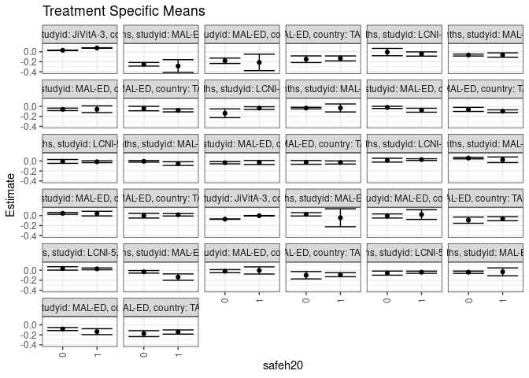

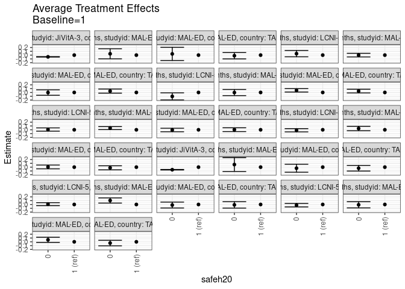

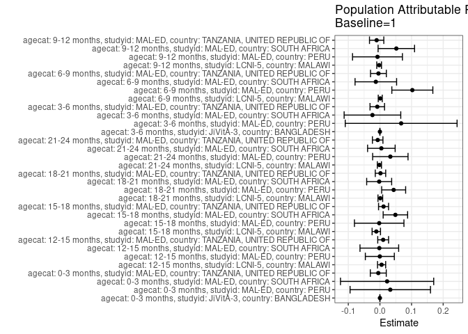

## Results Table

### Parameter: TSM

| agecat | studyid | country | intervention_level | baseline_level | estimate | ci_lower | ci_upper |
| --- | --- | --- | --- | --- | --- | --- | --- |
| 0-3 months | JiVitA-3 | BANGLADESH | 1 | NA | 0.0741773 | 0.0691196 | 0.0792350 |
| 0-3 months | JiVitA-3 | BANGLADESH | 0 | NA | 0.0281774 | 0.0235653 | 0.0327896 |
| 0-3 months | MAL-ED | PERU | 1 | NA | -0.2853442 | -0.4127172 | -0.1579713 |
| 0-3 months | MAL-ED | PERU | 0 | NA | -0.2508390 | -0.2864648 | -0.2152132 |
| 0-3 months | MAL-ED | SOUTH AFRICA | 1 | NA | -0.2126860 | -0.3771107 | -0.0482613 |
| 0-3 months | MAL-ED | SOUTH AFRICA | 0 | NA | -0.1811847 | -0.2348069 | -0.1275626 |
| 0-3 months | MAL-ED | TANZANIA, UNITED REPUBLIC OF | 1 | NA | -0.1337958 | -0.1834082 | -0.0841834 |
| 0-3 months | MAL-ED | TANZANIA, UNITED REPUBLIC OF | 0 | NA | -0.1499506 | -0.2165662 | -0.0833350 |
| 3-6 months | JiVitA-3 | BANGLADESH | 1 | NA | -0.0033703 | -0.0083531 | 0.0016125 |
| 3-6 months | JiVitA-3 | BANGLADESH | 0 | NA | -0.0709865 | -0.0748016 | -0.0671713 |
| 3-6 months | MAL-ED | PERU | 1 | NA | -0.0435003 | -0.2226802 | 0.1356796 |
| 3-6 months | MAL-ED | PERU | 0 | NA | 0.0243197 | -0.0087831 | 0.0574225 |
| 3-6 months | MAL-ED | SOUTH AFRICA | 1 | NA | 0.0203123 | -0.0760344 | 0.1166591 |
| 3-6 months | MAL-ED | SOUTH AFRICA | 0 | NA | -0.0080399 | -0.0495192 | 0.0334393 |
| 3-6 months | MAL-ED | TANZANIA, UNITED REPUBLIC OF | 1 | NA | -0.0631102 | -0.1029814 | -0.0232391 |
| 3-6 months | MAL-ED | TANZANIA, UNITED REPUBLIC OF | 0 | NA | -0.0914518 | -0.1529666 | -0.0299371 |
| 6-9 months | LCNI-5 | MALAWI | 1 | NA | 0.0268916 | 0.0089138 | 0.0448693 |
| 6-9 months | LCNI-5 | MALAWI | 0 | NA | 0.0355440 | 0.0013608 | 0.0697272 |
| 6-9 months | MAL-ED | PERU | 1 | NA | -0.1374352 | -0.2007075 | -0.0741629 |
| 6-9 months | MAL-ED | PERU | 0 | NA | -0.0326739 | -0.0580422 | -0.0073055 |
| 6-9 months | MAL-ED | SOUTH AFRICA | 1 | NA | -0.0048297 | -0.0760581 | 0.0663987 |
| 6-9 months | MAL-ED | SOUTH AFRICA | 0 | NA | -0.0193598 | -0.0503734 | 0.0116538 |
| 6-9 months | MAL-ED | TANZANIA, UNITED REPUBLIC OF | 1 | NA | -0.0904292 | -0.1307248 | -0.0501336 |
| 6-9 months | MAL-ED | TANZANIA, UNITED REPUBLIC OF | 0 | NA | -0.1002590 | -0.1736483 | -0.0268697 |
| 9-12 months | LCNI-5 | MALAWI | 1 | NA | -0.0407856 | -0.0624626 | -0.0191087 |
| 9-12 months | LCNI-5 | MALAWI | 0 | NA | -0.0585222 | -0.0993010 | -0.0177435 |
| 9-12 months | MAL-ED | PERU | 1 | NA | -0.0326081 | -0.1116005 | 0.0463844 |
| 9-12 months | MAL-ED | PERU | 0 | NA | -0.0406500 | -0.0632066 | -0.0180933 |
| 9-12 months | MAL-ED | SOUTH AFRICA | 1 | NA | -0.1365968 | -0.1957581 | -0.0774356 |
| 9-12 months | MAL-ED | SOUTH AFRICA | 0 | NA | -0.0840909 | -0.1141391 | -0.0540427 |
| 9-12 months | MAL-ED | TANZANIA, UNITED REPUBLIC OF | 1 | NA | -0.1436057 | -0.1854635 | -0.1017479 |
| 9-12 months | MAL-ED | TANZANIA, UNITED REPUBLIC OF | 0 | NA | -0.1760904 | -0.2356962 | -0.1164845 |
| 12-15 months | LCNI-5 | MALAWI | 1 | NA | -0.0456600 | -0.0878697 | -0.0034503 |
| 12-15 months | LCNI-5 | MALAWI | 0 | NA | -0.0070699 | -0.0799004 | 0.0657605 |
| 12-15 months | MAL-ED | PERU | 1 | NA | -0.0657169 | -0.1092700 | -0.0221637 |
| 12-15 months | MAL-ED | PERU | 0 | NA | -0.0660215 | -0.0851882 | -0.0468548 |
| 12-15 months | MAL-ED | SOUTH AFRICA | 1 | NA | -0.0581522 | -0.1250771 | 0.0087727 |
| 12-15 months | MAL-ED | SOUTH AFRICA | 0 | NA | -0.0603558 | -0.0851074 | -0.0356043 |
| 12-15 months | MAL-ED | TANZANIA, UNITED REPUBLIC OF | 1 | NA | -0.0803957 | -0.1107027 | -0.0500887 |
| 12-15 months | MAL-ED | TANZANIA, UNITED REPUBLIC OF | 0 | NA | -0.0442962 | -0.0884515 | -0.0001409 |
| 15-18 months | LCNI-5 | MALAWI | 1 | NA | -0.0349387 | -0.0612476 | -0.0086298 |
| 15-18 months | LCNI-5 | MALAWI | 0 | NA | -0.1383934 | -0.2266932 | -0.0500936 |
| 15-18 months | MAL-ED | PERU | 1 | NA | -0.0323292 | -0.1121274 | 0.0474690 |
| 15-18 months | MAL-ED | PERU | 0 | NA | -0.0347368 | -0.0509458 | -0.0185277 |
| 15-18 months | MAL-ED | SOUTH AFRICA | 1 | NA | -0.0773393 | -0.1171208 | -0.0375578 |
| 15-18 months | MAL-ED | SOUTH AFRICA | 0 | NA | -0.0212945 | -0.0425704 | -0.0000186 |
| 15-18 months | MAL-ED | TANZANIA, UNITED REPUBLIC OF | 1 | NA | -0.0972313 | -0.1241964 | -0.0702663 |
| 15-18 months | MAL-ED | TANZANIA, UNITED REPUBLIC OF | 0 | NA | -0.0613971 | -0.1020803 | -0.0207139 |
| 18-21 months | LCNI-5 | MALAWI | 1 | NA | -0.0160170 | -0.0341239 | 0.0020898 |
| 18-21 months | LCNI-5 | MALAWI | 0 | NA | -0.0090702 | -0.0479584 | 0.0298180 |
| 18-21 months | MAL-ED | PERU | 1 | NA | -0.0527482 | -0.0889320 | -0.0165645 |
| 18-21 months | MAL-ED | PERU | 0 | NA | -0.0074914 | -0.0233551 | 0.0083722 |
| 18-21 months | MAL-ED | SOUTH AFRICA | 1 | NA | -0.0300980 | -0.0700942 | 0.0098982 |
| 18-21 months | MAL-ED | SOUTH AFRICA | 0 | NA | -0.0350946 | -0.0570017 | -0.0131876 |
| 18-21 months | MAL-ED | TANZANIA, UNITED REPUBLIC OF | 1 | NA | -0.0306808 | -0.0616765 | 0.0003150 |
| 18-21 months | MAL-ED | TANZANIA, UNITED REPUBLIC OF | 0 | NA | -0.0282596 | -0.0652866 | 0.0087674 |
| 21-24 months | LCNI-5 | MALAWI | 1 | NA | 0.0274738 | 0.0107883 | 0.0441593 |
| 21-24 months | LCNI-5 | MALAWI | 0 | NA | 0.0151800 | -0.0239339 | 0.0542939 |
| 21-24 months | MAL-ED | PERU | 1 | NA | 0.0232134 | -0.0327597 | 0.0791864 |
| 21-24 months | MAL-ED | PERU | 0 | NA | 0.0574631 | 0.0416924 | 0.0732338 |
| 21-24 months | MAL-ED | SOUTH AFRICA | 1 | NA | 0.0395293 | -0.0069081 | 0.0859667 |
| 21-24 months | MAL-ED | SOUTH AFRICA | 0 | NA | 0.0449577 | 0.0264852 | 0.0634302 |
| 21-24 months | MAL-ED | TANZANIA, UNITED REPUBLIC OF | 1 | NA | 0.0153514 | -0.0086218 | 0.0393247 |
| 21-24 months | MAL-ED | TANZANIA, UNITED REPUBLIC OF | 0 | NA | -0.0022684 | -0.0489934 | 0.0444566 |

### Parameter: E(Y)

| agecat | studyid | country | intervention_level | baseline_level | estimate | ci_lower | ci_upper |
| --- | --- | --- | --- | --- | --- | --- | --- |
| 0-3 months | JiVitA-3 | BANGLADESH | NA | NA | 0.0740918 | 0.0691549 | 0.0790286 |
| 0-3 months | MAL-ED | PERU | NA | NA | -0.2525945 | -0.2869213 | -0.2182678 |
| 0-3 months | MAL-ED | SOUTH AFRICA | NA | NA | -0.1900029 | -0.2411148 | -0.1388910 |
| 0-3 months | MAL-ED | TANZANIA, UNITED REPUBLIC OF | NA | NA | -0.1389943 | -0.1784707 | -0.0995180 |
| 3-6 months | JiVitA-3 | BANGLADESH | NA | NA | -0.0034346 | -0.0083001 | 0.0014310 |
| 3-6 months | MAL-ED | PERU | NA | NA | 0.0236350 | -0.0084722 | 0.0557423 |
| 3-6 months | MAL-ED | SOUTH AFRICA | NA | NA | -0.0033394 | -0.0413034 | 0.0346246 |
| 3-6 months | MAL-ED | TANZANIA, UNITED REPUBLIC OF | NA | NA | -0.0714664 | -0.1037306 | -0.0392021 |
| 6-9 months | LCNI-5 | MALAWI | NA | NA | 0.0279334 | 0.0120046 | 0.0438622 |
| 6-9 months | MAL-ED | PERU | NA | NA | -0.0349381 | -0.0594933 | -0.0103830 |
| 6-9 months | MAL-ED | SOUTH AFRICA | NA | NA | -0.0177890 | -0.0460334 | 0.0104554 |
| 6-9 months | MAL-ED | TANZANIA, UNITED REPUBLIC OF | NA | NA | -0.0951251 | -0.1285712 | -0.0616789 |
| 9-12 months | LCNI-5 | MALAWI | NA | NA | -0.0433141 | -0.0626948 | -0.0239333 |
| 9-12 months | MAL-ED | PERU | NA | NA | -0.0403297 | -0.0622163 | -0.0184431 |
| 9-12 months | MAL-ED | SOUTH AFRICA | NA | NA | -0.0847380 | -0.1117373 | -0.0577388 |
| 9-12 months | MAL-ED | TANZANIA, UNITED REPUBLIC OF | NA | NA | -0.1539778 | -0.1878402 | -0.1201153 |
| 12-15 months | LCNI-5 | MALAWI | NA | NA | -0.0403575 | -0.0774359 | -0.0032790 |
| 12-15 months | MAL-ED | PERU | NA | NA | -0.0660102 | -0.0845347 | -0.0474856 |
| 12-15 months | MAL-ED | SOUTH AFRICA | NA | NA | -0.0600337 | -0.0829414 | -0.0371260 |
| 12-15 months | MAL-ED | TANZANIA, UNITED REPUBLIC OF | NA | NA | -0.0701548 | -0.0952743 | -0.0450353 |
| 15-18 months | LCNI-5 | MALAWI | NA | NA | -0.0464023 | -0.0722064 | -0.0205982 |
| 15-18 months | MAL-ED | PERU | NA | NA | -0.0346428 | -0.0505277 | -0.0187579 |
| 15-18 months | MAL-ED | SOUTH AFRICA | NA | NA | -0.0284295 | -0.0474993 | -0.0093597 |
| 15-18 months | MAL-ED | TANZANIA, UNITED REPUBLIC OF | NA | NA | -0.0857732 | -0.1082180 | -0.0633284 |
| 18-21 months | LCNI-5 | MALAWI | NA | NA | -0.0147327 | -0.0309734 | 0.0015080 |
| 18-21 months | MAL-ED | PERU | NA | NA | -0.0093386 | -0.0246779 | 0.0060006 |
| 18-21 months | MAL-ED | SOUTH AFRICA | NA | NA | -0.0324839 | -0.0517228 | -0.0132451 |
| 18-21 months | MAL-ED | TANZANIA, UNITED REPUBLIC OF | NA | NA | -0.0289082 | -0.0518906 | -0.0059258 |
| 21-24 months | LCNI-5 | MALAWI | NA | NA | 0.0258428 | 0.0105053 | 0.0411803 |
| 21-24 months | MAL-ED | PERU | NA | NA | 0.0561458 | 0.0407996 | 0.0714920 |
| 21-24 months | MAL-ED | SOUTH AFRICA | NA | NA | 0.0440882 | 0.0272574 | 0.0609190 |
| 21-24 months | MAL-ED | TANZANIA, UNITED REPUBLIC OF | NA | NA | 0.0082340 | -0.0135584 | 0.0300264 |

### Parameter: ATE

| agecat | studyid | country | intervention_level | baseline_level | estimate | ci_lower | ci_upper |
| --- | --- | --- | --- | --- | --- | --- | --- |
| 0-3 months | JiVitA-3 | BANGLADESH | 1 | 1 | 0.0000000 | 0.0000000 | 0.0000000 |
| 0-3 months | JiVitA-3 | BANGLADESH | 0 | 1 | -0.0459999 | -0.0526388 | -0.0393610 |
| 0-3 months | MAL-ED | PERU | 1 | 1 | 0.0000000 | 0.0000000 | 0.0000000 |
| 0-3 months | MAL-ED | PERU | 0 | 1 | 0.0345052 | -0.0977623 | 0.1667728 |
| 0-3 months | MAL-ED | SOUTH AFRICA | 1 | 1 | 0.0000000 | 0.0000000 | 0.0000000 |
| 0-3 months | MAL-ED | SOUTH AFRICA | 0 | 1 | 0.0315013 | -0.1423269 | 0.2053295 |
| 0-3 months | MAL-ED | TANZANIA, UNITED REPUBLIC OF | 1 | 1 | 0.0000000 | 0.0000000 | 0.0000000 |
| 0-3 months | MAL-ED | TANZANIA, UNITED REPUBLIC OF | 0 | 1 | -0.0161548 | -0.0992389 | 0.0669293 |
| 3-6 months | JiVitA-3 | BANGLADESH | 1 | 1 | 0.0000000 | 0.0000000 | 0.0000000 |
| 3-6 months | JiVitA-3 | BANGLADESH | 0 | 1 | -0.0676161 | -0.0737529 | -0.0614794 |
| 3-6 months | MAL-ED | PERU | 1 | 1 | 0.0000000 | 0.0000000 | 0.0000000 |
| 3-6 months | MAL-ED | PERU | 0 | 1 | 0.0678199 | -0.1142913 | 0.2499312 |
| 3-6 months | MAL-ED | SOUTH AFRICA | 1 | 1 | 0.0000000 | 0.0000000 | 0.0000000 |
| 3-6 months | MAL-ED | SOUTH AFRICA | 0 | 1 | -0.0283523 | -0.1333806 | 0.0766760 |
| 3-6 months | MAL-ED | TANZANIA, UNITED REPUBLIC OF | 1 | 1 | 0.0000000 | 0.0000000 | 0.0000000 |
| 3-6 months | MAL-ED | TANZANIA, UNITED REPUBLIC OF | 0 | 1 | -0.0283416 | -0.1022867 | 0.0456035 |
| 6-9 months | LCNI-5 | MALAWI | 1 | 1 | 0.0000000 | 0.0000000 | 0.0000000 |
| 6-9 months | LCNI-5 | MALAWI | 0 | 1 | 0.0086524 | -0.0300204 | 0.0473253 |
| 6-9 months | MAL-ED | PERU | 1 | 1 | 0.0000000 | 0.0000000 | 0.0000000 |
| 6-9 months | MAL-ED | PERU | 0 | 1 | 0.1047613 | 0.0367096 | 0.1728131 |
| 6-9 months | MAL-ED | SOUTH AFRICA | 1 | 1 | 0.0000000 | 0.0000000 | 0.0000000 |
| 6-9 months | MAL-ED | SOUTH AFRICA | 0 | 1 | -0.0145301 | -0.0923068 | 0.0632466 |
| 6-9 months | MAL-ED | TANZANIA, UNITED REPUBLIC OF | 1 | 1 | 0.0000000 | 0.0000000 | 0.0000000 |
| 6-9 months | MAL-ED | TANZANIA, UNITED REPUBLIC OF | 0 | 1 | -0.0098298 | -0.0944129 | 0.0747533 |
| 9-12 months | LCNI-5 | MALAWI | 1 | 1 | 0.0000000 | 0.0000000 | 0.0000000 |
| 9-12 months | LCNI-5 | MALAWI | 0 | 1 | -0.0177366 | -0.0638208 | 0.0283476 |
| 9-12 months | MAL-ED | PERU | 1 | 1 | 0.0000000 | 0.0000000 | 0.0000000 |
| 9-12 months | MAL-ED | PERU | 0 | 1 | -0.0080419 | -0.0901918 | 0.0741080 |
| 9-12 months | MAL-ED | SOUTH AFRICA | 1 | 1 | 0.0000000 | 0.0000000 | 0.0000000 |
| 9-12 months | MAL-ED | SOUTH AFRICA | 0 | 1 | 0.0525059 | -0.0150001 | 0.1200120 |
| 9-12 months | MAL-ED | TANZANIA, UNITED REPUBLIC OF | 1 | 1 | 0.0000000 | 0.0000000 | 0.0000000 |
| 9-12 months | MAL-ED | TANZANIA, UNITED REPUBLIC OF | 0 | 1 | -0.0324847 | -0.1059617 | 0.0409923 |
| 12-15 months | LCNI-5 | MALAWI | 1 | 1 | 0.0000000 | 0.0000000 | 0.0000000 |
| 12-15 months | LCNI-5 | MALAWI | 0 | 1 | 0.0385900 | -0.0446504 | 0.1218305 |
| 12-15 months | MAL-ED | PERU | 1 | 1 | 0.0000000 | 0.0000000 | 0.0000000 |
| 12-15 months | MAL-ED | PERU | 0 | 1 | -0.0003046 | -0.0478886 | 0.0472794 |
| 12-15 months | MAL-ED | SOUTH AFRICA | 1 | 1 | 0.0000000 | 0.0000000 | 0.0000000 |
| 12-15 months | MAL-ED | SOUTH AFRICA | 0 | 1 | -0.0022036 | -0.0740684 | 0.0696611 |
| 12-15 months | MAL-ED | TANZANIA, UNITED REPUBLIC OF | 1 | 1 | 0.0000000 | 0.0000000 | 0.0000000 |
| 12-15 months | MAL-ED | TANZANIA, UNITED REPUBLIC OF | 0 | 1 | 0.0360995 | -0.0177538 | 0.0899528 |
| 15-18 months | LCNI-5 | MALAWI | 1 | 1 | 0.0000000 | 0.0000000 | 0.0000000 |
| 15-18 months | LCNI-5 | MALAWI | 0 | 1 | -0.1034547 | -0.1961565 | -0.0107529 |
| 15-18 months | MAL-ED | PERU | 1 | 1 | 0.0000000 | 0.0000000 | 0.0000000 |
| 15-18 months | MAL-ED | PERU | 0 | 1 | -0.0024076 | -0.0838354 | 0.0790202 |
| 15-18 months | MAL-ED | SOUTH AFRICA | 1 | 1 | 0.0000000 | 0.0000000 | 0.0000000 |
| 15-18 months | MAL-ED | SOUTH AFRICA | 0 | 1 | 0.0560449 | 0.0108967 | 0.1011930 |
| 15-18 months | MAL-ED | TANZANIA, UNITED REPUBLIC OF | 1 | 1 | 0.0000000 | 0.0000000 | 0.0000000 |
| 15-18 months | MAL-ED | TANZANIA, UNITED REPUBLIC OF | 0 | 1 | 0.0358342 | -0.0130199 | 0.0846884 |
| 18-21 months | LCNI-5 | MALAWI | 1 | 1 | 0.0000000 | 0.0000000 | 0.0000000 |
| 18-21 months | LCNI-5 | MALAWI | 0 | 1 | 0.0069469 | -0.0359647 | 0.0498584 |
| 18-21 months | MAL-ED | PERU | 1 | 1 | 0.0000000 | 0.0000000 | 0.0000000 |
| 18-21 months | MAL-ED | PERU | 0 | 1 | 0.0452568 | 0.0057484 | 0.0847653 |
| 18-21 months | MAL-ED | SOUTH AFRICA | 1 | 1 | 0.0000000 | 0.0000000 | 0.0000000 |
| 18-21 months | MAL-ED | SOUTH AFRICA | 0 | 1 | -0.0049966 | -0.0512858 | 0.0412926 |
| 18-21 months | MAL-ED | TANZANIA, UNITED REPUBLIC OF | 1 | 1 | 0.0000000 | 0.0000000 | 0.0000000 |
| 18-21 months | MAL-ED | TANZANIA, UNITED REPUBLIC OF | 0 | 1 | 0.0024211 | -0.0473999 | 0.0522422 |
| 21-24 months | LCNI-5 | MALAWI | 1 | 1 | 0.0000000 | 0.0000000 | 0.0000000 |
| 21-24 months | LCNI-5 | MALAWI | 0 | 1 | -0.0122938 | -0.0547736 | 0.0301859 |
| 21-24 months | MAL-ED | PERU | 1 | 1 | 0.0000000 | 0.0000000 | 0.0000000 |
| 21-24 months | MAL-ED | PERU | 0 | 1 | 0.0342497 | -0.0239026 | 0.0924021 |
| 21-24 months | MAL-ED | SOUTH AFRICA | 1 | 1 | 0.0000000 | 0.0000000 | 0.0000000 |
| 21-24 months | MAL-ED | SOUTH AFRICA | 0 | 1 | 0.0054284 | -0.0445497 | 0.0554065 |
| 21-24 months | MAL-ED | TANZANIA, UNITED REPUBLIC OF | 1 | 1 | 0.0000000 | 0.0000000 | 0.0000000 |
| 21-24 months | MAL-ED | TANZANIA, UNITED REPUBLIC OF | 0 | 1 | -0.0176198 | -0.0702351 | 0.0349954 |

### Parameter: PAR

| agecat | studyid | country | intervention_level | baseline_level | estimate | ci_lower | ci_upper |
| --- | --- | --- | --- | --- | --- | --- | --- |
| 0-3 months | JiVitA-3 | BANGLADESH | 1 | NA | -0.0000855 | -0.0002489 | 0.0000779 |
| 0-3 months | MAL-ED | PERU | 1 | NA | 0.0327497 | -0.0943986 | 0.1598980 |
| 0-3 months | MAL-ED | SOUTH AFRICA | 1 | NA | 0.0226831 | -0.1247095 | 0.1700757 |
| 0-3 months | MAL-ED | TANZANIA, UNITED REPUBLIC OF | 1 | NA | -0.0051985 | -0.0304209 | 0.0200239 |
| 3-6 months | JiVitA-3 | BANGLADESH | 1 | NA | -0.0000642 | -0.0002259 | 0.0000975 |
| 3-6 months | MAL-ED | PERU | 1 | NA | 0.0671353 | -0.1097124 | 0.2439831 |
| 3-6 months | MAL-ED | SOUTH AFRICA | 1 | NA | -0.0236518 | -0.1131822 | 0.0658787 |
| 3-6 months | MAL-ED | TANZANIA, UNITED REPUBLIC OF | 1 | NA | -0.0083561 | -0.0313096 | 0.0145974 |
| 6-9 months | LCNI-5 | MALAWI | 1 | NA | 0.0010418 | -0.0053064 | 0.0073900 |
| 6-9 months | MAL-ED | PERU | 1 | NA | 0.1024971 | 0.0376673 | 0.1673268 |
| 6-9 months | MAL-ED | SOUTH AFRICA | 1 | NA | -0.0129593 | -0.0786415 | 0.0527230 |
| 6-9 months | MAL-ED | TANZANIA, UNITED REPUBLIC OF | 1 | NA | -0.0046958 | -0.0296930 | 0.0203013 |
| 9-12 months | LCNI-5 | MALAWI | 1 | NA | -0.0025284 | -0.0100070 | 0.0049502 |
| 9-12 months | MAL-ED | PERU | 1 | NA | -0.0077217 | -0.0866004 | 0.0711570 |
| 9-12 months | MAL-ED | SOUTH AFRICA | 1 | NA | 0.0518588 | -0.0057815 | 0.1094990 |
| 9-12 months | MAL-ED | TANZANIA, UNITED REPUBLIC OF | 1 | NA | -0.0103721 | -0.0329967 | 0.0122525 |
| 12-15 months | LCNI-5 | MALAWI | 1 | NA | 0.0053025 | -0.0075673 | 0.0181724 |
| 12-15 months | MAL-ED | PERU | 1 | NA | -0.0002933 | -0.0461067 | 0.0455202 |
| 12-15 months | MAL-ED | SOUTH AFRICA | 1 | NA | -0.0018815 | -0.0630088 | 0.0592458 |
| 12-15 months | MAL-ED | TANZANIA, UNITED REPUBLIC OF | 1 | NA | 0.0102409 | -0.0068756 | 0.0273574 |
| 15-18 months | LCNI-5 | MALAWI | 1 | NA | -0.0114636 | -0.0247556 | 0.0018285 |
| 15-18 months | MAL-ED | PERU | 1 | NA | -0.0023136 | -0.0805638 | 0.0759365 |
| 15-18 months | MAL-ED | SOUTH AFRICA | 1 | NA | 0.0489099 | 0.0102330 | 0.0875867 |
| 15-18 months | MAL-ED | TANZANIA, UNITED REPUBLIC OF | 1 | NA | 0.0114581 | -0.0043855 | 0.0273017 |
| 18-21 months | LCNI-5 | MALAWI | 1 | NA | 0.0012843 | -0.0061266 | 0.0086953 |
| 18-21 months | MAL-ED | PERU | 1 | NA | 0.0434096 | 0.0054929 | 0.0813263 |
| 18-21 months | MAL-ED | SOUTH AFRICA | 1 | NA | -0.0023859 | -0.0418908 | 0.0371189 |
| 18-21 months | MAL-ED | TANZANIA, UNITED REPUBLIC OF | 1 | NA | 0.0017725 | -0.0147113 | 0.0182564 |
| 21-24 months | LCNI-5 | MALAWI | 1 | NA | -0.0016310 | -0.0081890 | 0.0049270 |
| 21-24 months | MAL-ED | PERU | 1 | NA | 0.0329325 | -0.0229915 | 0.0888564 |
| 21-24 months | MAL-ED | SOUTH AFRICA | 1 | NA | 0.0045589 | -0.0390020 | 0.0481198 |
| 21-24 months | MAL-ED | TANZANIA, UNITED REPUBLIC OF | 1 | NA | -0.0071175 | -0.0237493 | 0.0095144 |